# Shashwat Jyotishi

## Project: HR Attrition Case Study using Machine Learning and Python

```python
import numpy as np
import pandas as pd
import seaborn as snb
from matplotlib import pyplot as plt
```

```python
df = pd.read_csv("datasets_11142_15488_HR_comma_sep.csv",encoding= 'latin')
```

```python
df.head(10)
```

|  | satisfaction_level | last_evaluation | number_project | average_montly_hours | time_spend_company | Work_accident | left | promotion_last_5years | Department | salary |
| --- | --- | --- | --- | --- | --- | --- | --- | --- | --- | --- |
| 0 | 0.38 | 0.53 | 2 | 157 | 3 | 0 | 1 | 0 | sales | low |
| 1 | 0.80 | 0.86 | 5 | 262 | 6 | 0 | 1 | 0 | sales | medium |
| 2 | 0.11 | 0.88 | 7 | 272 | 4 | 0 | 1 | 0 | sales | medium |
| 3 | 0.72 | 0.87 | 5 | 223 | 5 | 0 | 1 | 0 | sales | low |
| 4 | 0.37 | 0.52 | 2 | 159 | 3 | 0 | 1 | 0 | sales | low |
| 5 | 0.41 | 0.50 | 2 | 153 | 3 | 0 | 1 | 0 | sales | low |
| 6 | 0.10 | 0.77 | 6 | 247 | 4 | 0 | 1 | 0 | sales | low |
| 7 | 0.92 | 0.85 | 5 | 259 | 5 | 0 | 1 | 0 | sales | low |
| 8 | 0.89 | 1.00 | 5 | 224 | 5 | 0 | 1 | 0 | sales | low |
| 9 | 0.42 | 0.53 | 2 | 142 | 3 | 0 | 1 | 0 | sales | low |

```python
df["promotion_last_5years"].unique()
```

```
array([0, 1], dtype=int64)
```

```python
df.describe()
```

|  | satisfaction_level | last_evaluation | number_project | average_montly_hours | time_spend_company | Work_accident | left | promotion_last_5years |
| --- | --- | --- | --- | --- | --- | --- | --- | --- |
| count | 14999.000000 | 14999.000000 | 14999.000000 | 14999.000000 | 14999.000000 | 14999.000000 | 14999.000000 | 14999.000000 |
| mean | 0.612834 | 0.716102 | 3.803054 | 201.050337 | 3.498233 | 0.144610 | 0.238083 | 0.021268 |
| std | 0.248631 | 0.171169 | 1.232592 | 49.943099 | 1.460136 | 0.351719 | 0.425924 | 0.144281 |
| min | 0.090000 | 0.360000 | 2.000000 | 96.000000 | 2.000000 | 0.000000 | 0.000000 | 0.000000 |
| 25% | 0.440000 | 0.560000 | 3.000000 | 156.000000 | 3.000000 | 0.000000 | 0.000000 | 0.000000 |
| 50% | 0.640000 | 0.720000 | 4.000000 | 200.000000 | 3.000000 | 0.000000 | 0.000000 | 0.000000 |
| 75% | 0.820000 | 0.870000 | 5.000000 | 245.000000 | 4.000000 | 0.000000 | 0.000000 | 0.000000 |
| max | 1.000000 | 1.000000 | 7.000000 | 310.000000 | 10.000000 | 1.000000 | 1.000000 | 1.000000 |

```python
df.isnull().sum()
```

```
satisfaction_level       0
last_evaluation          0
number_project           0
average_montly_hours     0
time_spend_company       0
Work_accident            0
left                     0
promotion_last_5years    0
Department               0
salary                   0
dtype: int64
```

```python
df.groupby(["salary"]).mean()
```

| salary | satisfaction_level | last_evaluation | number_project | average_montly_hours | time_spend_company | Work_accident | left | promotion_last_5years |
| --- | --- | --- | --- | --- | --- | --- | --- | --- |
| high | 0.637470 | 0.704325 | 3.767179 | 199.867421 | 3.692805 | 0.155214 | 0.066289 | 0.058205 |
| low | 0.600753 | 0.717017 | 3.799891 | 200.996583 | 3.438218 | 0.142154 | 0.296884 | 0.009021 |
| medium | 0.621817 | 0.717322 | 3.813528 | 201.338349 | 3.529010 | 0.145361 | 0.204313 | 0.028079 |

```python
df.groupby(["Department"]).mean()
```

| Department | satisfaction_level | last_evaluation | number_project | average_montly_hours | time_spend_company | Work_accident | left | promotion_last_5years |
| --- | --- | --- | --- | --- | --- | --- | --- | --- |
| IT | 0.618142 | 0.716830 | 3.816626 | 202.215974 | 3.468623 | 0.133659 | 0.222494 | 0.002445 |
| RandD | 0.619822 | 0.712122 | 3.853875 | 200.800508 | 3.367217 | 0.170267 | 0.153748 | 0.034307 |
| accounting | 0.582151 | 0.717718 | 3.825293 | 201.162973 | 3.522816 | 0.125163 | 0.265971 | 0.018253 |
| hr | 0.598809 | 0.708850 | 3.654939 | 198.684709 | 3.355886 | 0.120433 | 0.290934 | 0.020298 |
| management | 0.621349 | 0.724000 | 3.860317 | 201.249206 | 4.303175 | 0.163492 | 0.144444 | 0.109524 |
| marketing | 0.618601 | 0.715886 | 3.687646 | 199.385781 | 3.569930 | 0.160839 | 0.236597 | 0.050117 |
| product_mng | 0.619634 | 0.714756 | 3.807095 | 199.965632 | 3.475610 | 0.146341 | 0.219512 | 0.000000 |
| sales | 0.614447 | 0.709717 | 3.776329 | 200.911353 | 3.534058 | 0.141787 | 0.244928 | 0.024155 |
| support | 0.618300 | 0.723109 | 3.803948 | 200.758188 | 3.393001 | 0.154778 | 0.248991 | 0.008973 |
| technical | 0.607897 | 0.721099 | 3.877941 | 202.497426 | 3.411397 | 0.140074 | 0.256250 | 0.010294 |

```python
df.groupby(["Department","salary"]).mean()
```

| Department | salary | satisfaction_level | last_evaluation | number_project | average_montly_hours | time_spend_company | Work_accident | left | promotion_last_5years |
| --- | --- | --- | --- | --- | --- | --- | --- | --- | --- |
| IT | high | 0.638193 | 0.716627 | 3.867470 | 194.927711 | 3.072289 | 0.048193 | 0.048193 | 0.000000 |
|  | low | 0.610099 | 0.715665 | 3.794745 | 201.382594 | 3.438424 | 0.146141 | 0.282430 | 0.003284 |
|  | medium | 0.624187 | 0.718187 | 3.833645 | 204.295327 | 3.564486 | 0.132710 | 0.181308 | 0.001869 |
| RandD | high | 0.586667 | 0.700588 | 3.764706 | 199.745098 | 3.529412 | 0.176471 | 0.078431 | 0.019608 |
|  | low | 0.623929 | 0.714176 | 3.804945 | 198.747253 | 3.381868 | 0.195055 | 0.151099 | 0.008242 |
|  | medium | 0.620349 | 0.711694 | 3.913978 | 202.954301 | 3.330645 | 0.145161 | 0.166667 | 0.061828 |
| accounting | high | 0.614054 | 0.724595 | 3.905405 | 205.905405 | 3.216216 | 0.202703 | 0.067568 | 0.081081 |
|  | low | 0.574162 | 0.713883 | 3.801676 | 199.899441 | 3.438547 | 0.111732 | 0.276536 | 0.005587 |
|  | medium | 0.583642 | 0.720299 | 3.832836 | 201.465672 | 3.680597 | 0.122388 | 0.298507 | 0.017910 |
| hr | high | 0.673111 | 0.743778 | 3.888889 | 209.066667 | 2.911111 | 0.088889 | 0.133333 | 0.044444 |
|  | low | 0.608657 | 0.717821 | 3.692537 | 202.456716 | 3.259701 | 0.137313 | 0.274627 | 0.005970 |
|  | medium | 0.580306 | 0.696100 | 3.590529 | 193.863510 | 3.501393 | 0.108635 | 0.325905 | 0.030641 |
| management | high | 0.653333 | 0.715822 | 3.777778 | 200.248889 | 5.164444 | 0.160000 | 0.004444 | 0.200000 |
|  | low | 0.610722 | 0.712833 | 3.777778 | 200.744444 | 3.411111 | 0.166667 | 0.327778 | 0.038889 |
|  | medium | 0.597867 | 0.741111 | 4.008889 | 202.653333 | 4.155556 | 0.164444 | 0.137778 | 0.075556 |
| marketing | high | 0.605250 | 0.663625 | 3.425000 | 185.575000 | 3.512500 | 0.162500 | 0.112500 | 0.062500 |
|  | low | 0.602910 | 0.727587 | 3.751244 | 204.487562 | 3.527363 | 0.154229 | 0.313433 | 0.027363 |
|  | medium | 0.638218 | 0.714495 | 3.675532 | 196.869681 | 3.627660 | 0.167553 | 0.180851 | 0.071809 |
| product_mng | high | 0.614118 | 0.665735 | 3.705882 | 194.632353 | 3.617647 | 0.191176 | 0.088235 | 0.000000 |
|  | low | 0.620909 | 0.725831 | 3.824834 | 201.048780 | 3.434590 | 0.150776 | 0.232816 | 0.000000 |
|  | medium | 0.619112 | 0.710418 | 3.804178 | 199.637076 | 3.498695 | 0.133159 | 0.227154 | 0.000000 |
| sales | high | 0.648959 | 0.699814 | 3.858736 | 201.178439 | 3.550186 | 0.137546 | 0.052045 | 0.044610 |
|  | low | 0.600838 | 0.709247 | 3.757980 | 200.363030 | 3.464030 | 0.126251 | 0.332063 | 0.009528 |
|  | medium | 0.625327 | 0.711778 | 3.785553 | 201.520316 | 3.614560 | 0.160835 | 0.170993 | 0.038375 |
| support | high | 0.655035 | 0.714113 | 3.794326 | 203.985816 | 3.219858 | 0.219858 | 0.056738 | 0.000000 |
|  | low | 0.591710 | 0.719494 | 3.787086 | 198.900524 | 3.484293 | 0.151832 | 0.339442 | 0.006108 |
|  | medium | 0.645149 | 0.728854 | 3.825902 | 202.535032 | 3.307856 | 0.148620 | 0.167728 | 0.013800 |
| technical | high | 0.625970 | 0.699453 | 3.651741 | 200.044776 | 3.313433 | 0.149254 | 0.124378 | 0.004975 |
|  | low | 0.594322 | 0.723367 | 3.910350 | 203.064869 | 3.397230 | 0.142128 | 0.275510 | 0.008746 |
|  | medium | 0.620968 | 0.722180 | 3.878814 | 202.248474 | 3.445510 | 0.136007 | 0.256321 | 0.013078 |

```python
df.groupby(["number_project" , "salary"]).mean()
```

| number_project | salary | satisfaction_level | last_evaluation | average_montly_hours | time_spend_company | Work_accident | left | promotion_last_5years |
| --- | --- | --- | --- | --- | --- | --- | --- | --- |
| 2 | high | 0.523357 | 0.617286 | 168.800000 | 3.407143 | 0.114286 | 0.328571 | 0.050000 |
|  | low | 0.470275 | 0.561540 | 159.134673 | 3.142113 | 0.085565 | 0.718750 | 0.008929 |
|  | medium | 0.484491 | 0.571305 | 160.828540 | 3.202434 | 0.100664 | 0.613938 | 0.019912 |
| 3 | high | 0.686985 | 0.718554 | 201.360294 | 3.654412 | 0.174020 | 0.007353 | 0.061275 |
|  | low | 0.683881 | 0.716857 | 196.793412 | 3.177554 | 0.180346 | 0.020659 | 0.013959 |
|  | medium | 0.691476 | 0.715862 | 197.349677 | 3.310884 | 0.170259 | 0.017241 | 0.024246 |
| 4 | high | 0.685435 | 0.705190 | 203.375000 | 3.644022 | 0.138587 | 0.005435 | 0.062500 |
|  | low | 0.697322 | 0.742971 | 206.056061 | 3.377096 | 0.166747 | 0.119310 | 0.010062 |
|  | medium | 0.694607 | 0.743482 | 204.438220 | 3.503665 | 0.148691 | 0.082723 | 0.038220 |
| 5 | high | 0.632694 | 0.722816 | 206.746939 | 3.726531 | 0.187755 | 0.061224 | 0.053061 |
|  | low | 0.689150 | 0.778352 | 212.885345 | 3.809415 | 0.135915 | 0.281701 | 0.003037 |
|  | medium | 0.677056 | 0.752068 | 212.242702 | 3.804837 | 0.159299 | 0.188490 | 0.027523 |
| 6 | high | 0.375753 | 0.719315 | 206.630137 | 4.575342 | 0.109589 | 0.178082 | 0.054795 |
|  | low | 0.251469 | 0.801596 | 242.791469 | 4.083728 | 0.116904 | 0.639810 | 0.006319 |
|  | medium | 0.287244 | 0.776688 | 238.153846 | 4.279915 | 0.111111 | 0.506410 | 0.025641 |
| 7 | high | 0.103333 | 0.850000 | 290.000000 | 4.000000 | 0.000000 | 1.000000 | 0.000000 |
|  | low | 0.112014 | 0.861250 | 278.201389 | 4.097222 | 0.006944 | 1.000000 | 0.000000 |
|  | medium | 0.127982 | 0.857706 | 272.889908 | 4.137615 | 0.027523 | 1.000000 | 0.000000 |

# Count Analysis

### Analysis of Salary with overall Data

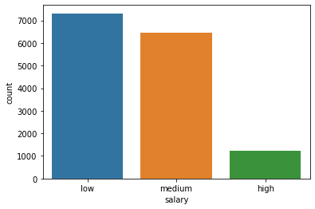

```python
snb.countplot(data = df , x = 'salary')
```

#### Report

We can see that the most number of employees are under the catagory of Low Salary. Also, we can interpret that there are relatively low number of employees whose salaries are considerd HIGH. We can sense this information naturally becouse people with high salary work on higher levels ie; they manage several number of employees under them.So the intution derived from the data is right.

### Analysis of Department with overall Data

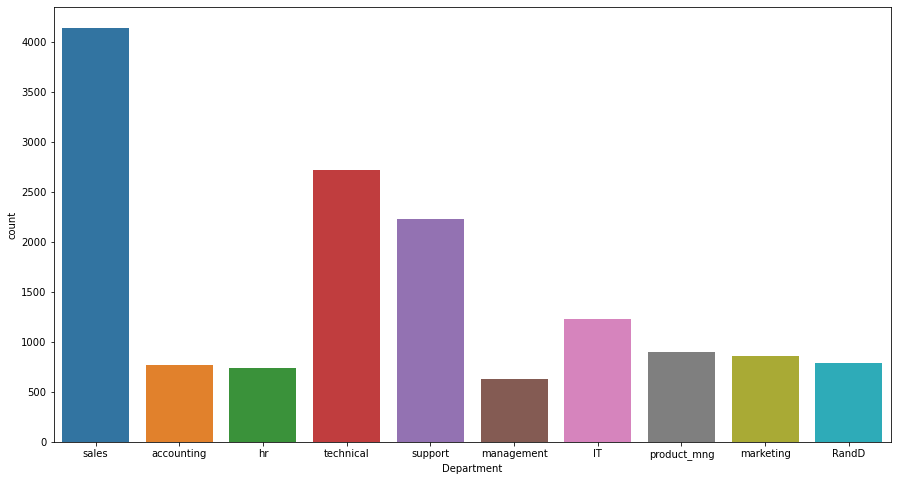

```python
plt.figure(figsize=(15,8))
snb.countplot(data = df , x = 'Department')
```

#### Report

The insight that we gain from the above graph is that the number of employees working under the Sales department is highest. By this graph, we can know and compare workforces under different Departments.

### Analysis of Departments with Salary

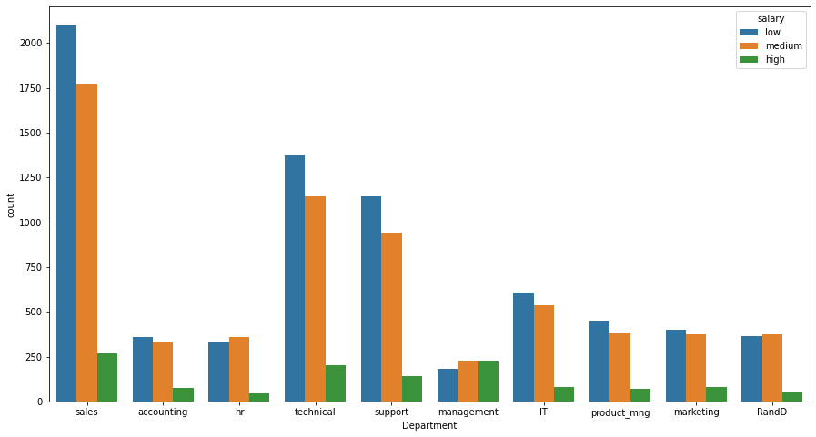

```python
plt.figure(figsize=(15,8))
snb.countplot(data = df , x = 'Department',hue="salary")
```

#### Report

By the above graph, we can analyze Salary Distribution of workforces under different Departments.

### Analyzing Relation between Number of Projects with Salary

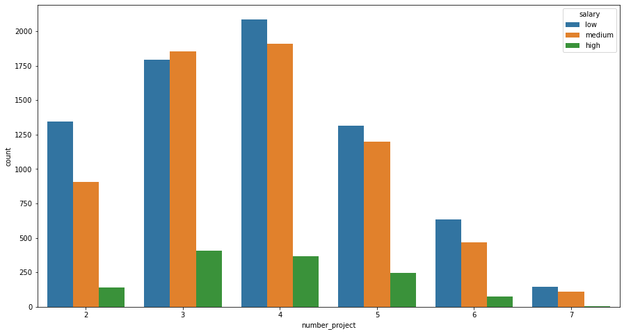

```python
plt.figure(figsize=(15,8))
snb.countplot(data = df , x = 'number_project',hue="salary")
```

### Analyzing Relationship between Number of Projects and Individual Departments

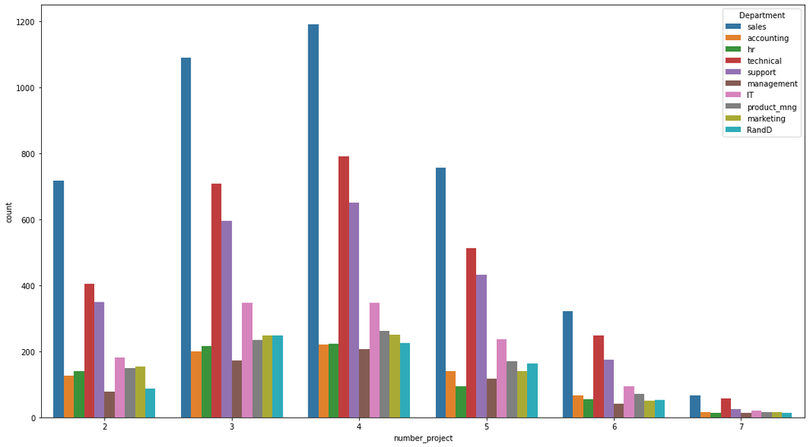

```python
plt.figure(figsize=(18,10))
snb.countplot(data = df , x = 'number_project',hue="Department")
```

#### Report

Here, we compare different different departments based on the number of projects undergoing in each and every one of them.

### Analyzing Relationship between Time spent in the company by employees and their current Salary Tag

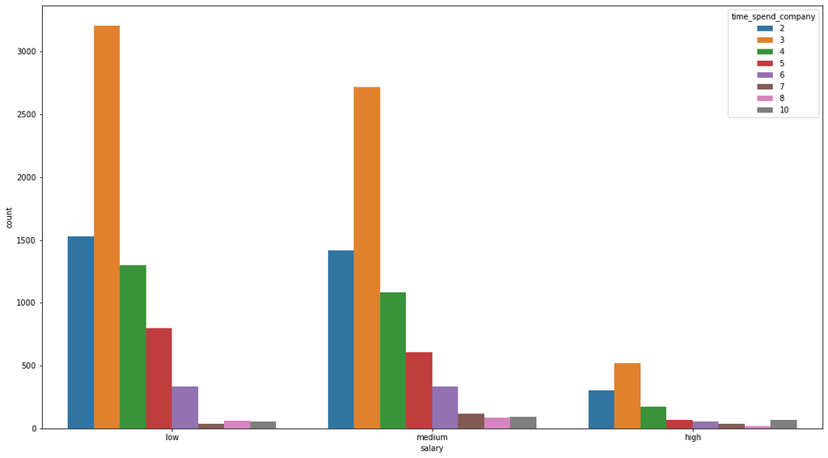

```python
plt.figure(figsize=(18,10))
snb.countplot(data = df , x = 'salary',hue="time_spend_company")
```

#### Report

Here, we can see that for every salary tag, the most number of employees are of 3 year of experience in the company. A major workforce has spent 3 years in the same company.

### Analyzing Work Accident data

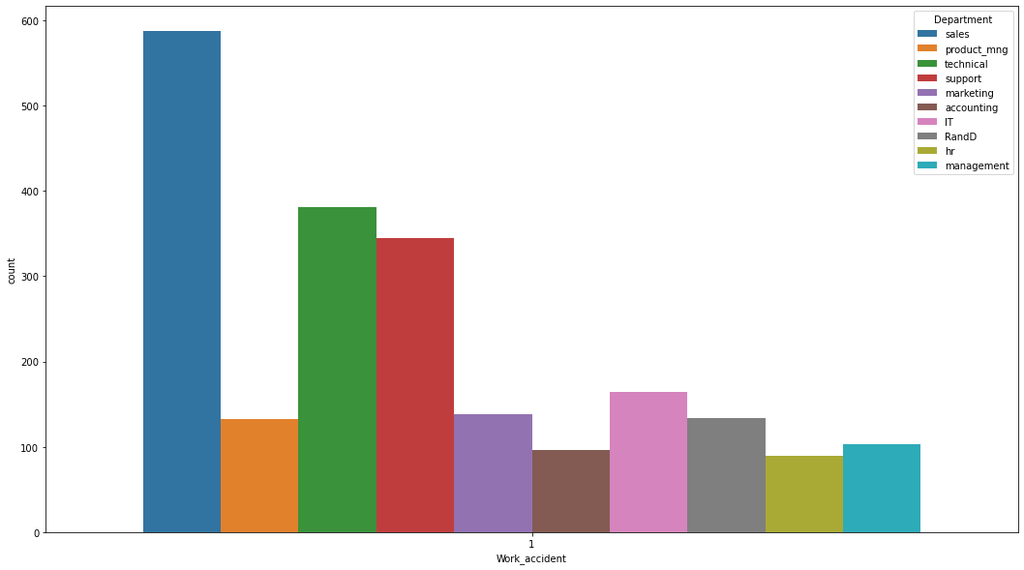

```python
plt.figure(figsize=(18,10))
df1 = df[df["Work_accident"]==1]
snb.countplot(data = df1 , x = 'Work_accident',hue="Department")
```

#### Report

Here, we can see that the most number of work accidents that happened in the company are from the Sales Department.

### Analyzing Number of Promotions in various Departments

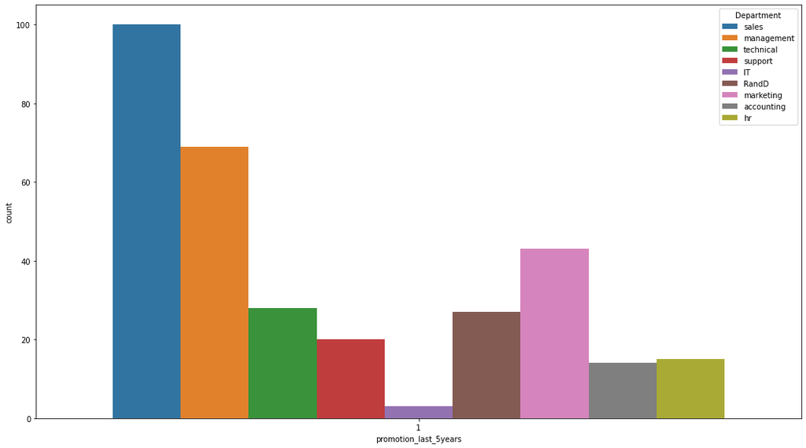

```python
plt.figure(figsize=(18,10))
df1 = df[df["promotion_last_5years"]==1]
snb.countplot(data = df1 , x = 'promotion_last_5years',hue="Department")
```

#### Report

# Boxplot Analysis

```python
df.head(10)
```

|  | satisfaction_level | last_evaluation | number_project | average_montly_hours | time_spend_company | Work_accident | left | promotion_last_5years | Department | salary |
| --- | --- | --- | --- | --- | --- | --- | --- | --- | --- | --- |
| 0 | 0.38 | 0.53 | 2 | 157 | 3 | 0 | 1 | 0 | sales | low |
| 1 | 0.80 | 0.86 | 5 | 262 | 6 | 0 | 1 | 0 | sales | medium |
| 2 | 0.11 | 0.88 | 7 | 272 | 4 | 0 | 1 | 0 | sales | medium |
| 3 | 0.72 | 0.87 | 5 | 223 | 5 | 0 | 1 | 0 | sales | low |
| 4 | 0.37 | 0.52 | 2 | 159 | 3 | 0 | 1 | 0 | sales | low |
| 5 | 0.41 | 0.50 | 2 | 153 | 3 | 0 | 1 | 0 | sales | low |
| 6 | 0.10 | 0.77 | 6 | 247 | 4 | 0 | 1 | 0 | sales | low |
| 7 | 0.92 | 0.85 | 5 | 259 | 5 | 0 | 1 | 0 | sales | low |
| 8 | 0.89 | 1.00 | 5 | 224 | 5 | 0 | 1 | 0 | sales | low |
| 9 | 0.42 | 0.53 | 2 | 142 | 3 | 0 | 1 | 0 | sales | low |

### Analyzing satisfaction range with salary

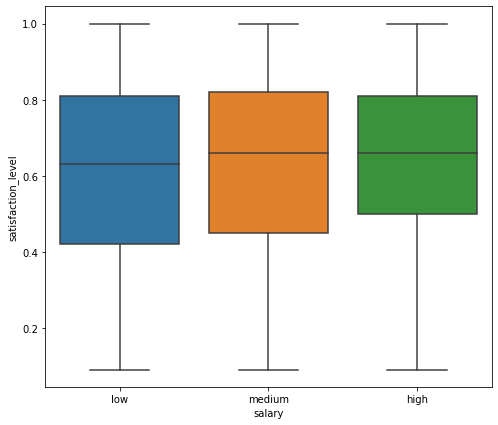

```python
plt.figure(figsize=(8,7))
snb.boxplot( y = 'satisfaction_level' ,x ='salary' , data = df)
```

#### Report

Here, we can see that the average number of employees with low salary tags are less satisfied as compared to high salary tag ones.

### Analyzing Range of Average Working hours under Various Departments

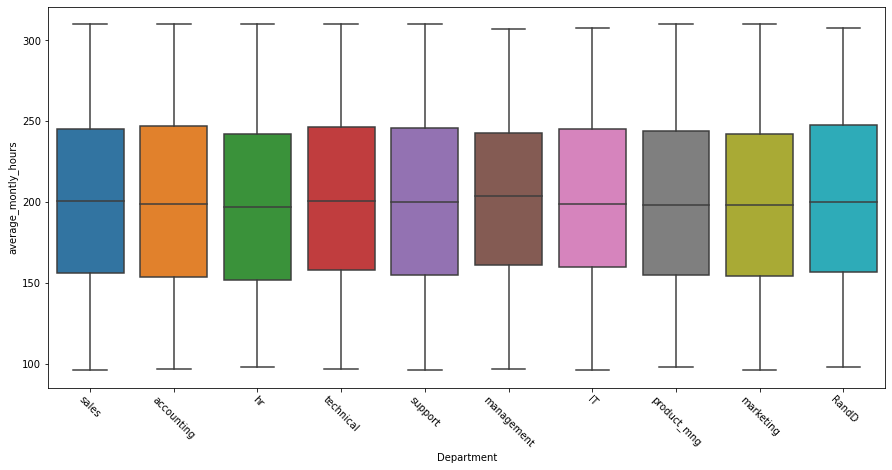

```python
plt.figure(figsize=(15,7))
snb.boxplot( y = 'average_montly_hours' ,x ='Department' , data = df)
plt.xticks( rotation = -45)
```

#### Report

Here, we can see that almost every department works for the same duration of time.

### Analyzing Satisfaction with years spent in the company

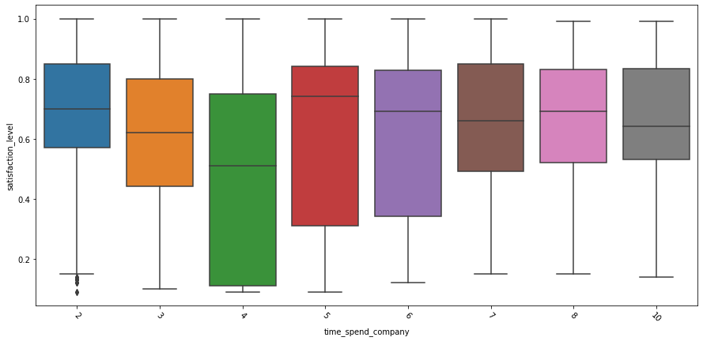

```python
plt.figure(figsize=(15,7))
snb.boxplot( y = 'satisfaction_level' ,x ='time_spend_company' , data = df)
plt.xticks( rotation = -45)
```

### Analyzing Quitting of jobs of People

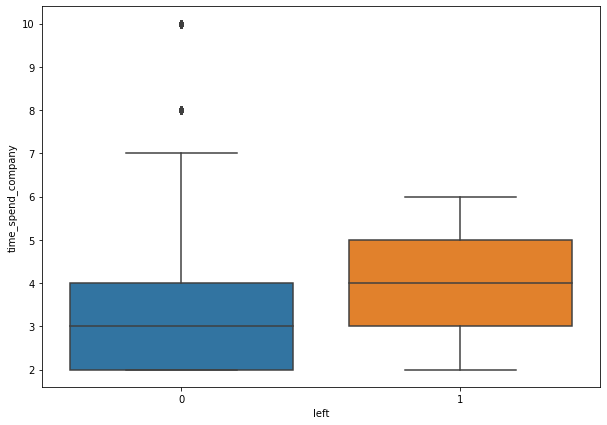

```python
plt.figure(figsize=(10,7))
snb.boxplot( y = 'time_spend_company' ,x ='left' , data = df)
```

#### Report

Here, we can see that most number of people quit their job after 4 years. We can also see that the most unsatisfied workforce belongs to the group of 4 years experience. Therefore, company has to improve its policy and check on how they can ameliorate the work enviroment of people belonging to 4 years experience group.

## Further Data Processing

### Categorising Satisfaction into labels

```python
def labelling(avg_sat):
    if avg_sat >=0.80:
        return 'A'
    if avg_sat >=0.50:
        return 'B'
    if avg_sat >=0.30:
        return 'C'
    if avg_sat >=0.20:
        return 'D'
    if avg_sat >=0.10:
        return 'E'
    return "F"
```

```python
df['Satisfaction'] =df.apply(lambda x : labelling(x['satisfaction_level']) ,axis =1)
df
```

|  | satisfaction_level | last_evaluation | number_project | average_montly_hours | time_spend_company | Work_accident | left | promotion_last_5years | Department | salary | Satisfaction |
| --- | --- | --- | --- | --- | --- | --- | --- | --- | --- | --- | --- |
| 0 | 0.38 | 0.53 | 2 | 157 | 3 | 0 | 1 | 0 | sales | low | C |
| 1 | 0.80 | 0.86 | 5 | 262 | 6 | 0 | 1 | 0 | sales | medium | A |
| 2 | 0.11 | 0.88 | 7 | 272 | 4 | 0 | 1 | 0 | sales | medium | E |
| 3 | 0.72 | 0.87 | 5 | 223 | 5 | 0 | 1 | 0 | sales | low | B |
| 4 | 0.37 | 0.52 | 2 | 159 | 3 | 0 | 1 | 0 | sales | low | C |
| ... | ... | ... | ... | ... | ... | ... | ... | ... | ... | ... | ... |
| 14994 | 0.40 | 0.57 | 2 | 151 | 3 | 0 | 1 | 0 | support | low | C |
| 14995 | 0.37 | 0.48 | 2 | 160 | 3 | 0 | 1 | 0 | support | low | C |
| 14996 | 0.37 | 0.53 | 2 | 143 | 3 | 0 | 1 | 0 | support | low | C |
| 14997 | 0.11 | 0.96 | 6 | 280 | 4 | 0 | 1 | 0 | support | low | E |
| 14998 | 0.37 | 0.52 | 2 | 158 | 3 | 0 | 1 | 0 | support | low | C |

14999 rows × 11 columns

```python
df["Satisfaction"].value_counts()
```

```
B    6192
A    4224
C    2681
E    1214
D     493
F     195
Name: Satisfaction, dtype: int64
```

### Evaluating employees on last evaluation

```python
df['Pass_Status'] = np.where(df['last_evaluation']<0.50 , 'F','P')
```

```python
df
```

|  | satisfaction_level | last_evaluation | number_project | average_montly_hours | time_spend_company | Work_accident | left | promotion_last_5years | Department | salary | Satisfaction | Pass_Status |
| --- | --- | --- | --- | --- | --- | --- | --- | --- | --- | --- | --- | --- |
| 0 | 0.38 | 0.53 | 2 | 157 | 3 | 0 | 1 | 0 | sales | low | C | P |
| 1 | 0.80 | 0.86 | 5 | 262 | 6 | 0 | 1 | 0 | sales | medium | A | P |
| 2 | 0.11 | 0.88 | 7 | 272 | 4 | 0 | 1 | 0 | sales | medium | E | P |
| 3 | 0.72 | 0.87 | 5 | 223 | 5 | 0 | 1 | 0 | sales | low | B | P |
| 4 | 0.37 | 0.52 | 2 | 159 | 3 | 0 | 1 | 0 | sales | low | C | P |
| ... | ... | ... | ... | ... | ... | ... | ... | ... | ... | ... | ... | ... |
| 14994 | 0.40 | 0.57 | 2 | 151 | 3 | 0 | 1 | 0 | support | low | C | P |
| 14995 | 0.37 | 0.48 | 2 | 160 | 3 | 0 | 1 | 0 | support | low | C | F |
| 14996 | 0.37 | 0.53 | 2 | 143 | 3 | 0 | 1 | 0 | support | low | C | P |
| 14997 | 0.11 | 0.96 | 6 | 280 | 4 | 0 | 1 | 0 | support | low | E | P |
| 14998 | 0.37 | 0.52 | 2 | 158 | 3 | 0 | 1 | 0 | support | low | C | P |

14999 rows × 12 columns

## Data Analysis

### Analyzing Satisfaction Range

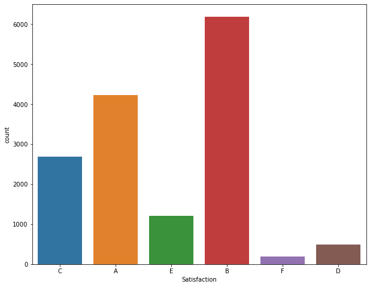

```python
plt.figure(figsize=(10,8))
snb.countplot(data = df , x = 'Satisfaction')
```

#### Report

Here, we can see that the most number of employees lie between the satisfaction range of 0.5 to 0.8.

### Analyzing Report of Last Evaluation

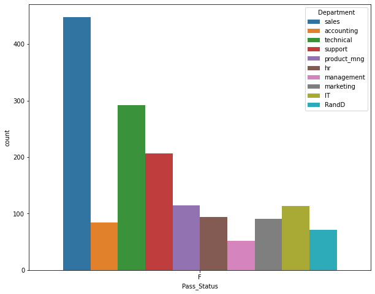

```python
plt.figure(figsize=(10,8))
snb.countplot(data = df[df["Pass_Status"]=="F"] , x = 'Pass_Status',hue = "Department")
```

#### Report

Here, we can see the number of employees failing deaprtment-wise. So, here we can see that most of the employees from sales department got less than 0.5 marks in evaluating.

## Analysis of satisfaction level with salary tag

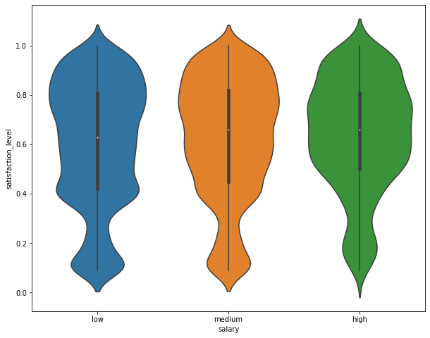

```python
plt.figure(figsize=(10,8))
snb.violinplot( x = df["salary"], y = df["satisfaction_level"] )
```

#### Report

Here, we can see that in high salary ta, there is relatively low number of less satisfaction_rating , that means high pay grade employees are relatively more satisfied.

## Deducing Relationship between Various Columns

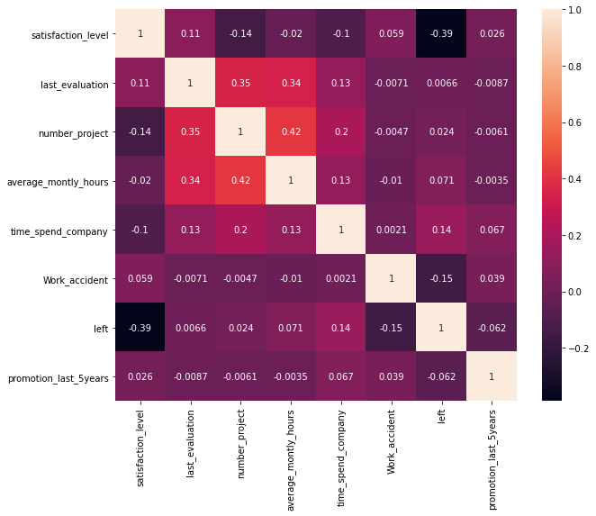

```python
# dataset = sns.load_dataset('tips')
plt.figure(figsize=(10,8))
tc = df.corr()
snb.heatmap(tc,annot = True)
```

#### Report

Here, we can see that the correlation of number of projects and average monthly hours is highest. Therefore, we can deduce that these two factors are highly co-related i.e. these two columns depend on each other. Here, correlation shows linear relation between left and satisfaction level.

### Let us Dive into the analysis of people who are leaving the Job

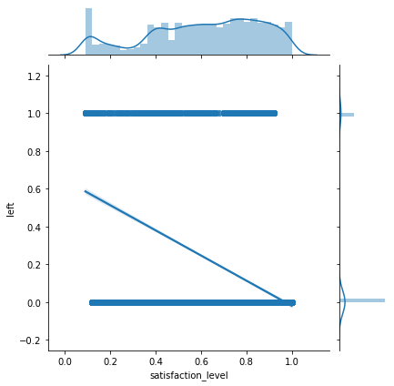

```python
snb.jointplot(x='satisfaction_level', y='left', data=df,kind = "reg" )
```

#### Report

Here, we can see that people who tend to leave the job tend to have low satisfaction rating.

# Let us build a Machine Learning Model which can predict if an employee would quit or not depending on the all the details.

```python
from sklearn.linear_model import LogisticRegression
from sklearn.model_selection import train_test_split
from sklearn import linear_model
```

```python
dept_dummies = pd.get_dummies(df.Department)
```

```python
dataset = df.drop(['Department'], 1).join(sales_dummies)
```

```python
dataset.salary = dataset.salary.astype('category').cat.reorder_categories(['low', 'medium', 'high'])
```

```python
salary_numeric = pd.DataFrame(dataset.salary.cat.codes)
salary_numeric.columns = ['salary']
```

```python
dataset = dataset.drop(['salary'], 1).join(salary_numeric)
```

```python
dataset
```

|  | satisfaction_level | last_evaluation | number_project | average_montly_hours | time_spend_company | Work_accident | left | promotion_last_5years | Satisfaction | Pass_Status | ... | RandD | accounting | hr | management | marketing | product_mng | sales | support | technical | salary |
| --- | --- | --- | --- | --- | --- | --- | --- | --- | --- | --- | --- | --- | --- | --- | --- | --- | --- | --- | --- | --- | --- |
| 0 | 0.38 | 0.53 | 2 | 157 | 3 | 0 | 1 | 0 | C | P | ... | 0 | 0 | 0 | 0 | 0 | 0 | 1 | 0 | 0 | 0 |
| 1 | 0.80 | 0.86 | 5 | 262 | 6 | 0 | 1 | 0 | A | P | ... | 0 | 0 | 0 | 0 | 0 | 0 | 1 | 0 | 0 | 1 |
| 2 | 0.11 | 0.88 | 7 | 272 | 4 | 0 | 1 | 0 | E | P | ... | 0 | 0 | 0 | 0 | 0 | 0 | 1 | 0 | 0 | 1 |
| 3 | 0.72 | 0.87 | 5 | 223 | 5 | 0 | 1 | 0 | B | P | ... | 0 | 0 | 0 | 0 | 0 | 0 | 1 | 0 | 0 | 0 |
| 4 | 0.37 | 0.52 | 2 | 159 | 3 | 0 | 1 | 0 | C | P | ... | 0 | 0 | 0 | 0 | 0 | 0 | 1 | 0 | 0 | 0 |
| ... | ... | ... | ... | ... | ... | ... | ... | ... | ... | ... | ... | ... | ... | ... | ... | ... | ... | ... | ... | ... | ... |
| 14994 | 0.40 | 0.57 | 2 | 151 | 3 | 0 | 1 | 0 | C | P | ... | 0 | 0 | 0 | 0 | 0 | 0 | 0 | 1 | 0 | 0 |
| 14995 | 0.37 | 0.48 | 2 | 160 | 3 | 0 | 1 | 0 | C | F | ... | 0 | 0 | 0 | 0 | 0 | 0 | 0 | 1 | 0 | 0 |
| 14996 | 0.37 | 0.53 | 2 | 143 | 3 | 0 | 1 | 0 | C | P | ... | 0 | 0 | 0 | 0 | 0 | 0 | 0 | 1 | 0 | 0 |
| 14997 | 0.11 | 0.96 | 6 | 280 | 4 | 0 | 1 | 0 | E | P | ... | 0 | 0 | 0 | 0 | 0 | 0 | 0 | 1 | 0 | 0 |
| 14998 | 0.37 | 0.52 | 2 | 158 | 3 | 0 | 1 | 0 | C | P | ... | 0 | 0 | 0 | 0 | 0 | 0 | 0 | 1 | 0 | 0 |

14999 rows × 21 columns

```python
X = dataset.drop(['left',"Satisfaction","Pass_Status"], 1)
y = dataset.left
x_train, x_test, y_train, y_test = train_test_split(X, y, test_size=.15,
                                                    random_state=6)
```

```python
 logisticRegr=linear_model.LogisticRegression(penalty='l2', solver='liblinear',
                                      tol=1e-9, max_iter=int(1e9),
                                      warm_start=True,
                                      intercept_scaling=10000.)
```

```python
logisticRegr.fit(x_train, y_train)
```

```
LogisticRegression(intercept_scaling=10000.0, max_iter=1000000000,
                   solver='liblinear', tol=1e-09, warm_start=True)
```

```python
predictions = logisticRegr.predict(x_test)
```

```python
score = logisticRegr.score(x_test, y_test)
print(score)
```

```
0.7933333333333333
```

#### Report

We Developed a classifier which can predict the the decision made by an employee. The decision is regarding if he or she would quit or not.